# Ash_A07

Plotting JAGS output

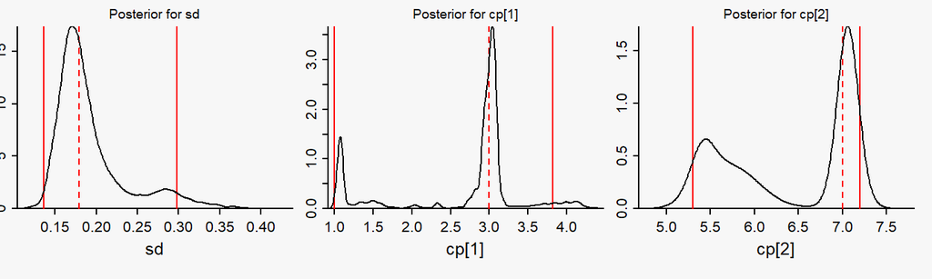

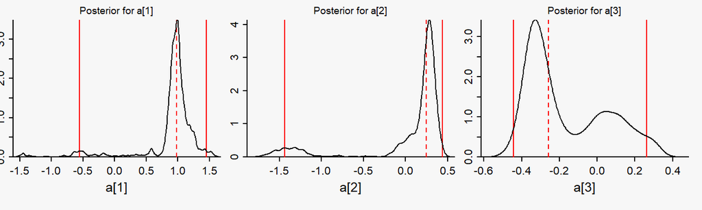

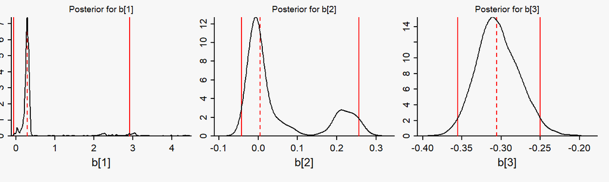

```r
sams1 <- as.matrix(rjo$mcmc) # extract samples
## add SD as a column
sams  <- cbind(sd=sqrt(dof/(dof-2)/sams1[,"tau"]), sams1)
## delete the tau column
sams  <- sams[ , colnames(sams) != "tau"]
med   <- {}
names <- c("sd","a", "b")

## plot prep
mypar(mfrow=c(1, 3), tcl=-0.3, xaxs="i", yaxs="i",
      mar=c(4, 1, 1.5, 1))
for (nam in colnames(sams)) { # loop over variable names/plot panels

  den      <- density(sams[ , nam]) # density histogram for nam
  ylim     <- c(0, max(den$y)) #ylimit for HPDI lines
  med[nam] <- median(sams[ , nam]) #median
  qs       <- HDIofMCMC(sams[ ,nam]) # 95% HPDI

  plot(den$x, den$y, type="l", lwd=1, col="black", ylim=ylim,
       main=paste("Posterior for", nam),
       xlab="", ylab="")
  title( xlab=nam, cex.lab=1.2, line=1.8 )
  abline(v=med[nam], col="red", lty=2)   ## median
  lines(rep(qs[1], 2), c(0, ylim[2]), col="red")# 95% HPDI
  lines(rep(qs[2], 2), c(0, ylim[2]), col="red")# 95% HPDI
  lines(den$x, den$y) ## re-plot density on top
  #legend("topright", bty="n", title="Posteriors", lty=c(1, 2, 1, 1),
  #col=c("black", "red", "red", "skyblue"), cex=0.95,
  #inset=c(0.03, 0.0), lwd=c(1, 1, 1, 2),
  #legend=c("density", "median", "95% HPDI", "true"))
}
```

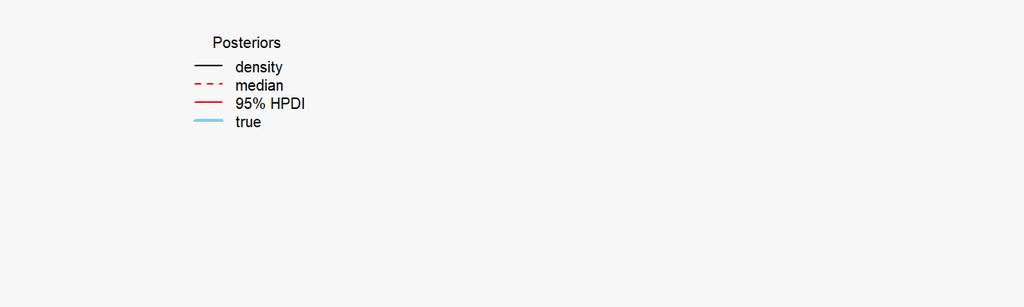

```r
  plot(0, 0, type="n", xlim=c(0,1), ylim=c(0,1), axes=FALSE, xlab="", ylab="")
  # text(0.5,0.5,"Put your\nlegend here")
  legend("topright", bty="n", title="Posteriors", lty=c(1, 2, 1, 1),
       col=c("black", "red", "red", "skyblue"), cex=0.95,
       inset=c(0.03, 0.0), lwd=c(1, 1, 1, 2),
       legend=c("density", "median", "95% HPDI", "true"))
```

# Ex 5. Diagnostics

(15 pts) Use Kruschke’s function `diagMCMC()` to create a figure of diagnostics for `cp[1]` and `a`. Discuss. Hint: First open `DBDA2E-utilities.R` in RStudio. There are many useful functions in there, and a table of contents at the beginning to help you navigate.

```r
sams1 <- as.matrix(rjo$mcmc) # extract samples
diagMCMC(rjo$mcmc, parName=varnames(rjo$mcmc)[1])

for (i in 3:5){
 diagMCMC(rjo$mcmc, parName=varnames(rjo$mcmc)[i])
}
```

[output not shown]

Checking results

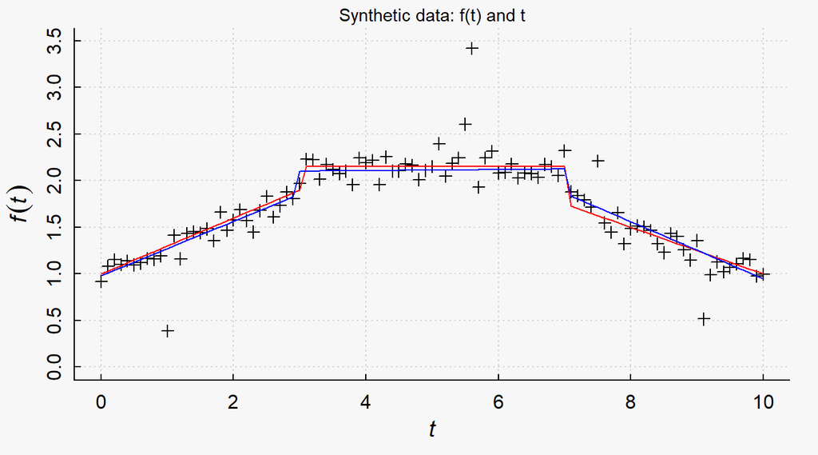

Figure 7: Ploting the simulated data (black cross hairs) overlayed by the know mean (red line) and the mean found by the BUGS-JAGS simulation (blue line)

```r
a2 <- med[4:6]
b2 <- med[7:9]
ab2 <- data.frame(a=c(a2[[1]], a2[[2]], a2[[3]]), b=c(b2[[1]], b2[[2]], b2[[3]]))

mu2 <- f(t1, ab2, 1) + (t > med[2])*f(t2, ab2, 2) + (t > med[3])*f(t3, ab2, 3)

mypar()
xlab <- expression(italic(t))
ylab <- expression(italic(f(t)))
plot(t, y, type="p", pch=3, xlab="", ylab="", ylim=c(0, 3.5),
     panel.first=grid(), cex.lab=1.1)
title(main="Synthetic data: f(t) and t", xlab=xlab, ylab=ylab, cex.lab=1.2)
lines(t, mu, col='red')
lines(t, mu2, col='blue')
```

[^1]: If you are looking at the code that made the figure, note for later use that you cannot create new functions in JAGS as easily as in R. They have to be written in C++. I am too lazy to learn C++, so I just “spell out” a function in JAGS every time I need it. The Stan language for MCMC makes it easy to create new functions, but the Stan language is a bit like C++, i.e., more difficult than JAGS to code.
[^2]: Note for later use: you can code the $t_1,t_2,t_3$ in JAGS, and JAGS has a function called `step()`. The math $H(t-\xi_1)$ becomes `step(t[i]-cp[1])` where the change point `cp[1]` is $\xi_1$.